# Pemodelan ARIMA Data NVDA

# Packages

```r
library(ggplot2)
library(tsibble)
library(tseries)
library(MASS)
library(forecast)
library(TSA)
library(TTR)
library(aTSA)
library(graphics)
```

# Input Data

```r
# Membaca data
nvda <- read.csv("C:\\Users\\HP\\OneDrive\\Documents\\nvda_us_d.csv")

# Mengubah Date menjadi format tanggal
nvda$Date <- as.Date(nvda$Date)

# Melihat struktur data
str(nvda)
```

```
## 'data.frame':    1003 obs. of  6 variables:
##  $ Date  : Date, format: "2022-01-03" "2022-01-04" ...
##  $ Open  : num  29.8 30.2 28.9 27.6 28.1 ...
##  $ High  : num  30.7 30.4 29.4 28.4 28.4 ...
##  $ Low   : num  29.7 28.3 27.5 27 27 ...
##  $ Close : num  30.1 29.2 27.6 28.1 27.2 ...
##  $ Volume: int  393055570 528031140 498892235 454941757 410620306 595670001 404761355 384051161 539764316 396490679 ...
```

```r
# Membuat deret waktu berdasarkan harga penutupan
nvda.ts <- ts(nvda$Close)

# Melihat jumlah observasi
length(nvda.ts)
```

```
## [1] 1003
```

# Eksplorasi Data

## Plot Data Penuh

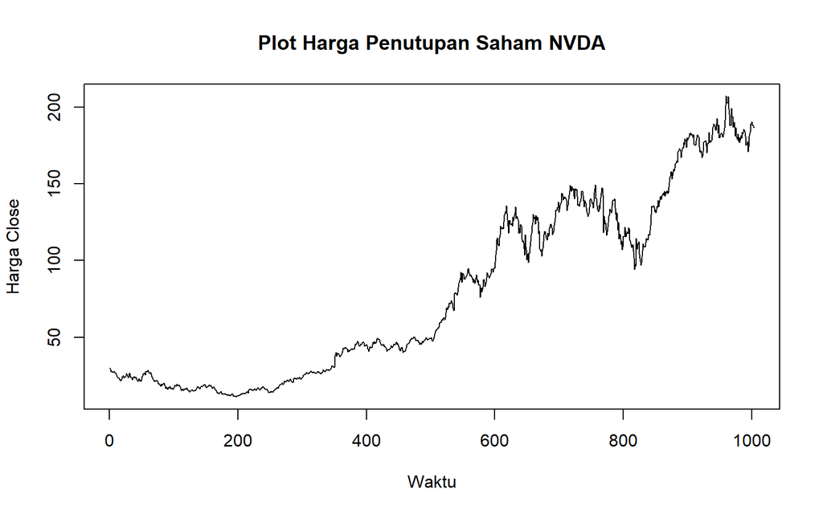

```r
plot(nvda.ts,
     lty = 1,
     xlab = "Waktu",
     ylab = "Harga Close",
     main = "Plot Harga Penutupan Saham NVDA")
```

# Pembagian Data Train dan Test

```r
# Pembagian data 86% : 14%
n <- length(nvda.ts)
n_train <- floor(0.86 * n)

train.ts <- nvda.ts[1:n_train]
test.ts <- nvda.ts[(n_train + 1):n]

length(train.ts)
```

```
## [1] 862
```

```r
length(test.ts)
```

```
## [1] 141
```

## Plot Data Latih

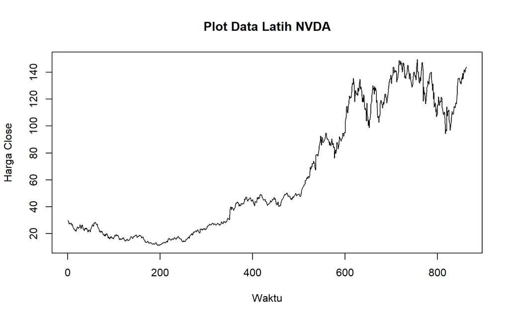

```r
plot.ts(train.ts,
        lty = 1,
        xlab = "Waktu",
        ylab = "Harga Close",
        main = "Plot Data Latih NVDA")
```

## Plot Data Uji

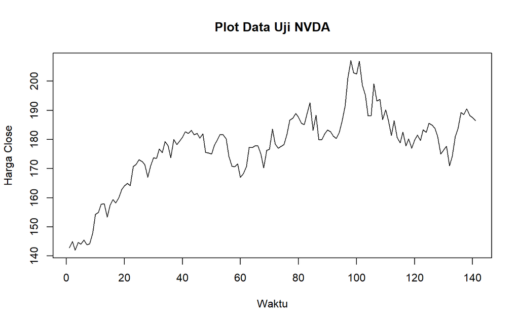

```r
plot.ts(test.ts,
        lty = 1,
        xlab = "Waktu",
        ylab = "Harga Close",
        main = "Plot Data Uji NVDA")
```

# Uji Stasioneritas Data

## Plot ACF

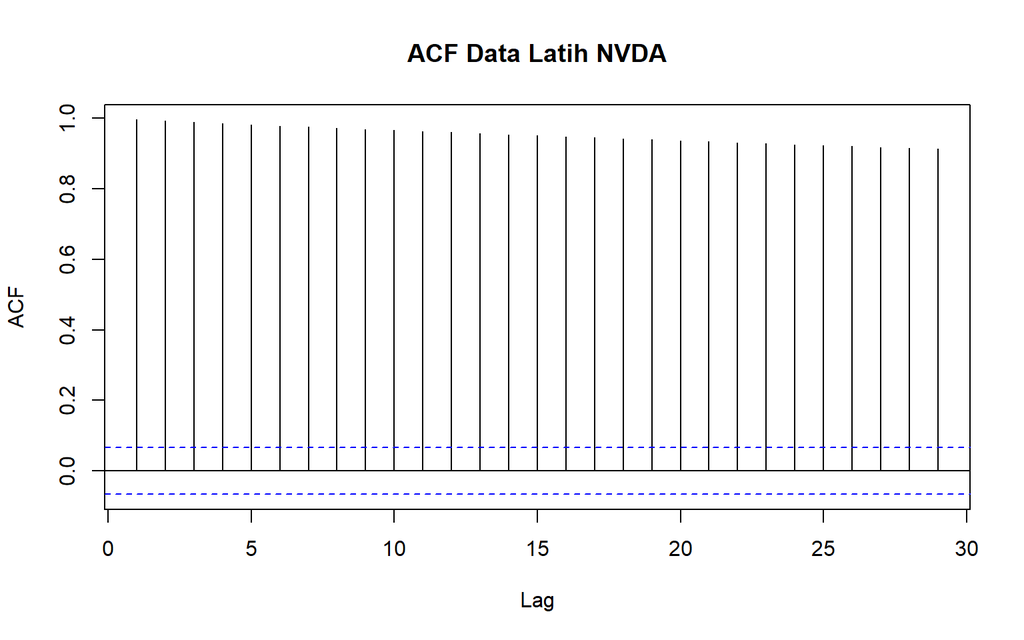

```r
acf(train.ts,
    main = "ACF Data Latih NVDA")
```

## Uji ADF

$H_0 : \text{Data tidak stasioner dalam rataan}$  
$H_1 : \text{Data stasioner dalam rataan}$

```r
tseries::adf.test(train.ts)
```

```
##
##  Augmented Dickey-Fuller Test
##
## data:  train.ts
## Dickey-Fuller = -2.4492, Lag order = 9, p-value = 0.3882
## alternative hypothesis: stationary
```

Data harga penutupan saham NVDA belum stasioner dalam rataan. Oleh karena itu, diperlukan penanganan ketidakstasioneran sebelum dilakukan pemodelan ARIMA.

## Plot Box-Cox

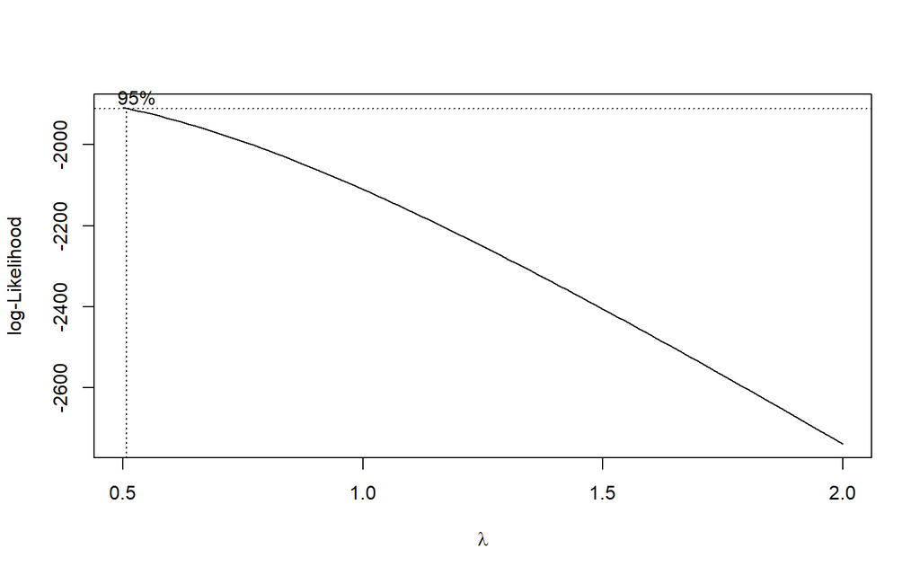

```r
library(MASS)

index <- seq(1:length(train.ts))

bc <- boxcox(
  train.ts ~ index,
  lambda = seq(0.5, 2, by = 0.1)
)
```

```r
# Lambda optimum
lambda_opt <- bc$x[which.max(bc$y)]
lambda_opt
```

```
## [1] 0.5
```

```r
# Selang kepercayaan 95%
ci_lambda <- bc$x[
  bc$y > max(bc$y) -
    0.5 * qchisq(0.95, df = 1)
]

ci_lower <- min(ci_lambda)
ci_upper <- max(ci_lambda)

c(
  Batas_Bawah = ci_lower,
  Batas_Atas = ci_upper
)
```

```
## Batas_Bawah  Batas_Atas
##         0.5         0.5
```

Berdasarkan plot di atas, data NVDA juga tidak stasioner dalam ragam karena selangnya tidak memuat angka 1.

# Penanganan Ketidakstasioneran (Differencing Pertama)

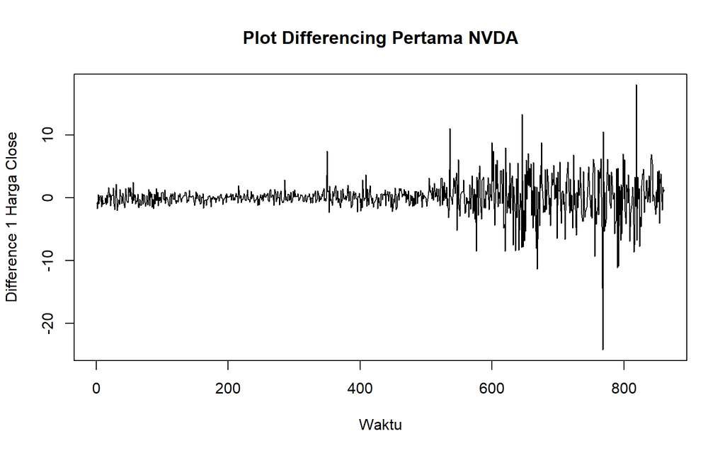

```r
train.diff <- diff(train.ts, differences = 1)

plot.ts(
  train.diff,
  lty = 1,
  xlab = "Waktu",
  ylab = "Difference 1 Harga Close",
  main = "Plot Differencing Pertama NVDA"
)
```

Setelah differencing pertama, data tidak lagi menunjukkan tren naik seperti data asli.

# Uji Stasioner Setelah Differencing

## ACF

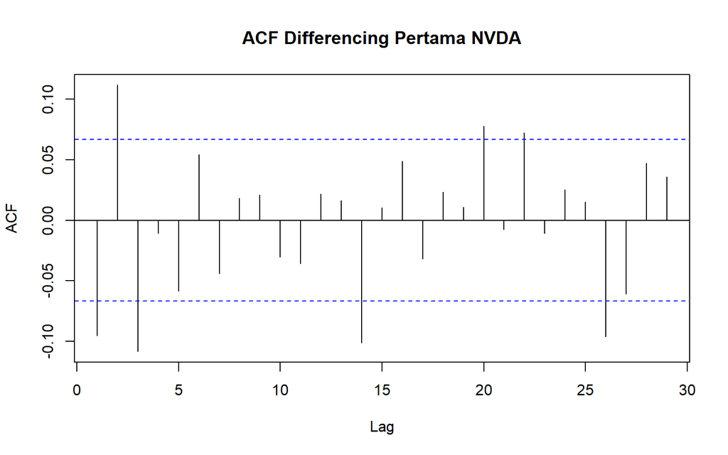

```r
acf(train.diff,
    main = "ACF Differencing Pertama NVDA")
```

## Uji ADF

```r
tseries::adf.test(train.diff)
```

```
##
##  Augmented Dickey-Fuller Test
##
## data:  train.diff
## Dickey-Fuller = -9.7458, Lag order = 9, p-value = 0.01
## alternative hypothesis: stationary
```

Karena p-value < 0.05 , maka Tolak H0. Setelah dilakukan differencing pertama, data sudah stasioner dalam rataan. Dengan demikian, ketidakstasioneran dalam rataan telah berhasil ditangani.

## Plot Box-Cox

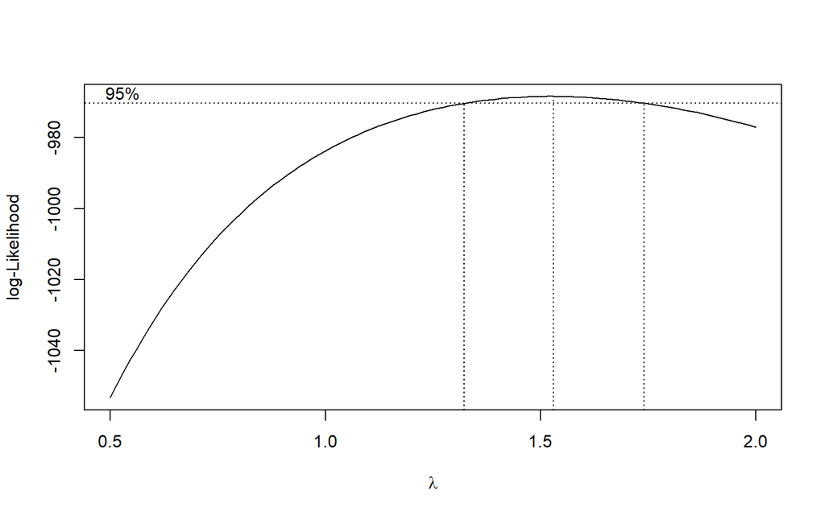

```r
index_diff <- seq(1:length(train.diff))

min_val <- min(train.diff)

if (min_val <= 0) {
  c_shift <- abs(min_val) + 1
  train.diff_shifted <- train.diff + c_shift
} else {
  train.diff_shifted <- train.diff
}

bc_diff <- boxcox(
  train.diff_shifted ~ index_diff,
  lambda = seq(0.5, 2, by = 0.1)
)
```

```r
lambda_opt_diff <- bc_diff$x[which.max(bc_diff$y)]

print(
  paste(
    "Lambda optimum setelah differencing:",
    lambda_opt_diff
  )
)
```

```
## [1] "Lambda optimum setelah differencing: 1.53030303030303"
```

```r
ci_lambda_diff <- bc_diff$x[
  bc_diff$y >
    max(bc_diff$y) -
    0.5 * qchisq(0.95, df = 1)
]

ci_lower_diff <- min(ci_lambda_diff)
ci_upper_diff <- max(ci_lambda_diff)

c(
  Batas_Bawah = ci_lower_diff,
  Batas_Atas = ci_upper_diff
)
```

```
## Batas_Bawah  Batas_Atas
##    1.333333    1.727273
```

Setelah dilakukan differencing, ternyata data masih belum stasioner dalam ragam.

# Transformasi Setelah Differencing

Karena hasil uji Box-Cox setelah differencing menunjukkan bahwa selang kepercayaan lambda tidak memuat angka 1, maka data hasil differencing perlu ditransformasi terlebih dahulu untuk menstabilkan ragam.

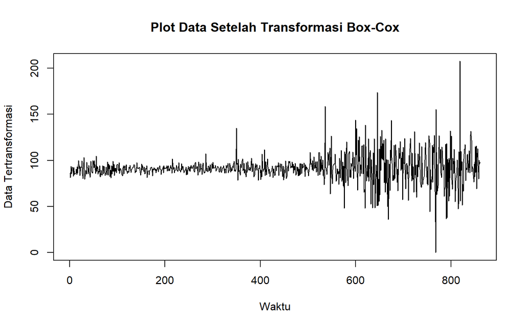

```r
if (ci_lower_diff > 1 | ci_upper_diff < 1) {

  if (abs(lambda_opt_diff) < 1e-8) {
    train.trans <- log(train.diff_shifted)
  } else {
    train.trans <- (
      train.diff_shifted^lambda_opt_diff - 1
    ) / lambda_opt_diff
  }

  transformasi_dilakukan <- TRUE

  plot.ts(
    train.trans,
    lty = 1,
    xlab = "Waktu",
    ylab = "Data Tertransformasi",
    main = "Plot Data Setelah Transformasi Box-Cox"
  )

} else {

  train.trans <- train.diff
  transformasi_dilakukan <- FALSE

  plot.ts(
    train.trans,
    lty = 1,
    xlab = "Waktu",
    ylab = "Difference 1 Harga Close",
    main = "Plot Data Setelah Pemeriksaan Box-Cox"
  )
}
```

```r
transformasi_dilakukan
```

```
## [1] TRUE
```

Setelah transformasi dilakukan, stasioneritas dalam rataan dan ragam diperiksa kembali.

# Uji Stasioneritas Setelah Transformasi

## ACF

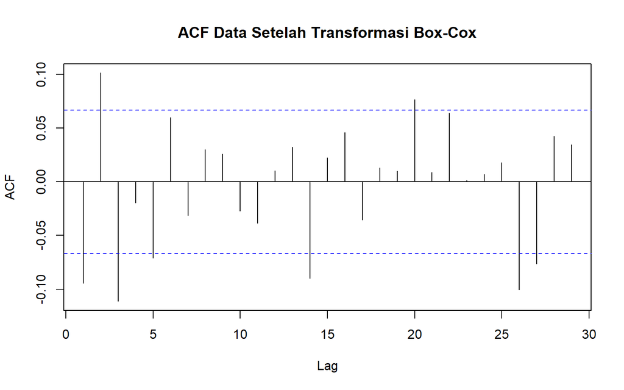

```r
acf(
  train.trans,
  main = "ACF Data Setelah Transformasi Box-Cox"
)
```

## Uji AD

```r
tseries::adf.test(train.trans)
```

```
##
##  Augmented Dickey-Fuller Test
##
## data:  train.trans
## Dickey-Fuller = -9.8311, Lag order = 9, p-value = 0.01
## alternative hypothesis: stationary
```

Karean p-value < 0.05, maka Tolak H0 sehingga data hasil transformasi sudah stasioner dalam rataan.

## Uji Box-Cox

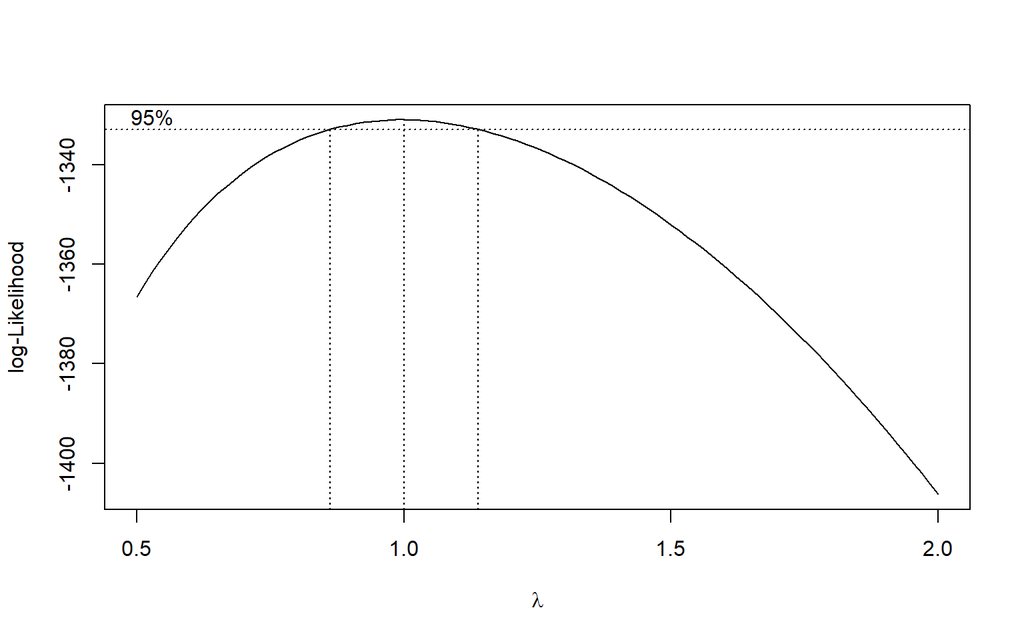

```r
# Box-Cox membutuhkan data positif.
# Jika masih terdapat nilai <= 0, lakukan pergeseran sementara.

min_trans <- min(train.trans)

if (min_trans <= 0) {
  c_shift_trans <- abs(min_trans) + 1
  train.trans_shifted <- train.trans + c_shift_trans
} else {
  c_shift_trans <- 0
  train.trans_shifted <- train.trans
}

index_trans <- seq(1:length(train.trans_shifted))

bc_trans <- boxcox(
  train.trans_shifted ~ index_trans,
  lambda = seq(0.5, 2, by = 0.1)
)
```

```r
lambda_opt_trans <- bc_trans$x[which.max(bc_trans$y)]

print(
  paste(
    "Lambda optimum setelah transformasi:",
    lambda_opt_trans
  )
)
```

```
## [1] "Lambda optimum setelah transformasi: 1"
```

```r
ci_lambda_trans <- bc_trans$x[
  bc_trans$y >
    max(bc_trans$y) -
    0.5 * qchisq(0.95, df = 1)
]

ci_lower_trans <- min(ci_lambda_trans)
ci_upper_trans <- max(ci_lambda_trans)

c(
  Batas_Bawah = ci_lower_trans,
  Batas_Atas = ci_upper_trans
)
```

```
## Batas_Bawah  Batas_Atas
##   0.8636364   1.1363636
```

Karena selang kepercayaan lambda hasil pemeriksaan ulang memuat angka 1, maka ragam data hasil transformasi sudah stasioner.

Untuk keperluan identifikasi model, digunakan data hasil transformasi sebagai data akhir.

```r
train.final <- train.trans
```

# Identifikasi Model

## ACF

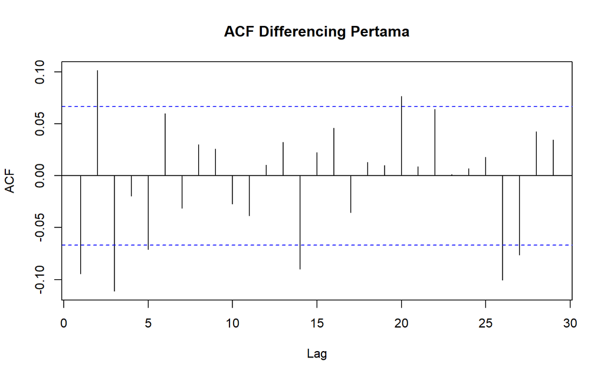

```r
acf(train.final,
    main = "ACF Differencing Pertama")
```

Kandidat: ARIMA(0,1,1)

## PACF

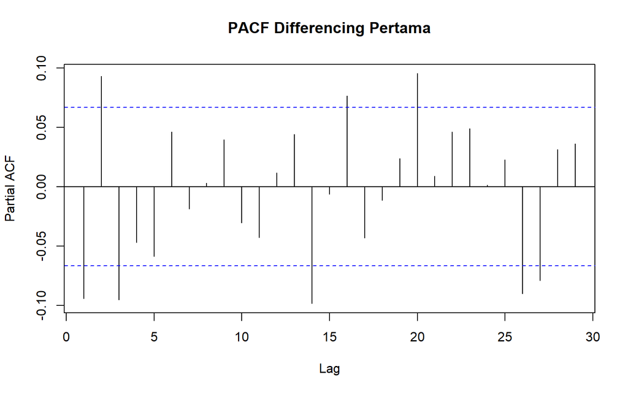

```r
pacf(train.final,
     main = "PACF Differencing Pertama")
```

Kandidat: ARIMA(1,1,0), ARIMA (1,1,1)

## EACF

```r
eacf(train.final)
```

```
## AR/MA
##   0 1 2 3 4 5 6 7 8 9 10 11 12 13
## 0 x x x o x o o o o o o  o  o  x
## 1 x o x o o o o o o o o  o  o  x
## 2 x o x x x o o o o o o  o  o  o
## 3 x x x x o o o o o o o  o  o  o
## 4 x x x x o x o o o o o  o  o  o
## 5 x x o x x o o o o o o  o  o  o
## 6 x x o x x x o o o o o  o  o  o
## 7 x o x x o o x o o o o  o  o  o
```

Kandidat : ARIMA(0,1,3), ARIMA(1,1,4)

# Pendugaan Parameter Model

## Model 1 ARIMA (0,1,1)

```r
model1 <- Arima(
  train.final,
  order = c(0,0,1),
  method = "ML"
)

summary(model1)
```

```
## Series: train.final
## ARIMA(0,0,1) with non-zero mean
##
## Coefficients:
##           ma1     mean
##       -0.0808  91.6675
## s.e.   0.0317   0.4561
##
## sigma^2 = 212.4:  log likelihood = -3527.53
## AIC=7061.07   AICc=7061.09   BIC=7075.34
##
## Training set error measures:
##                         ME     RMSE      MAE  MPE MAPE      MASE         ACF1
## Training set -0.0006522266 14.55706 8.882688 -Inf  Inf 0.6912905 -0.006814683
```

```r
lmtest::coeftest(model1)
```

```
##
## z test of coefficients:
##
##            Estimate Std. Error  z value Pr(>|z|)
## ma1       -0.080771   0.031701  -2.5479  0.01084 *
## intercept 91.667512   0.456079 200.9904  < 2e-16 ***
## ---
## Signif. codes:  0 '***' 0.001 '**' 0.01 '*' 0.05 '.' 0.1 ' ' 1
```

## Model 2 ARIMA (1,1,0)

```r
model2 <- Arima(
  train.final,
  order = c(1,0,0),
  method = "ML"
)

summary(model2)
```

```
## Series: train.final
## ARIMA(1,0,0) with non-zero mean
##
## Coefficients:
##           ar1     mean
##       -0.0943  91.6675
## s.e.   0.0339   0.4531
##
## sigma^2 = 212.1:  log likelihood = -3526.95
## AIC=7059.91   AICc=7059.93   BIC=7074.18
##
## Training set error measures:
##                         ME     RMSE      MAE  MPE MAPE      MASE        ACF1
## Training set -0.0006512691 14.54724 8.883408 -Inf  Inf 0.6913466 0.008696059
```

```r
lmtest::coeftest(model2)
```

```
##
## z test of coefficients:
##
##            Estimate Std. Error  z value  Pr(>|z|)
## ar1       -0.094276   0.033918  -2.7795  0.005444 **
## intercept 91.667506   0.453102 202.3110 < 2.2e-16 ***
## ---
## Signif. codes:  0 '***' 0.001 '**' 0.01 '*' 0.05 '.' 0.1 ' ' 1
```

## Model 3 ARIMA (1,1,1)

```r
model3 <- Arima(
  train.final,
  order = c(1,0,1),
  method = "ML"
)

summary(model3)
```

```
## Series: train.final
## ARIMA(1,0,1) with non-zero mean
##
## Coefficients:
##           ar1     ma1     mean
##       -0.7865  0.6928  91.6661
## s.e.   0.0881  0.1020   0.4665
##
## sigma^2 = 209.4:  log likelihood = -3520.96
## AIC=7049.92   AICc=7049.96   BIC=7068.95
##
## Training set error measures:
##                        ME     RMSE      MAE  MPE MAPE      MASE       ACF1
## Training set 0.0005731465 14.44602 8.835212 -Inf  Inf 0.6875958 0.01753591
```

```r
lmtest::coeftest(model3)
```

```
##
## z test of coefficients:
##
##            Estimate Std. Error  z value  Pr(>|z|)
## ar1       -0.786516   0.088058  -8.9318 < 2.2e-16 ***
## ma1        0.692750   0.101957   6.7945 1.087e-11 ***
## intercept 91.666127   0.466497 196.4991 < 2.2e-16 ***
## ---
## Signif. codes:  0 '***' 0.001 '**' 0.01 '*' 0.05 '.' 0.1 ' ' 1
```

## Model 4 ARIMA (0,1,3)

```r
model4 <- Arima(
  train.final,
  order = c(0,0,3),
  method = "ML"
)

summary(model4)
```

```
## Series: train.final
## ARIMA(0,0,3) with non-zero mean
##
## Coefficients:
##           ma1     ma2      ma3     mean
##       -0.0875  0.0914  -0.0996  91.6669
## s.e.   0.0344  0.0360   0.0326   0.4446
##
## sigma^2 = 209:  log likelihood = -3519.57
## AIC=7049.13   AICc=7049.2   BIC=7072.92
##
## Training set error measures:
##                        ME     RMSE      MAE  MPE MAPE      MASE        ACF1
## Training set -0.001226522 14.42261 8.872667 -Inf  Inf 0.6905107 0.004622973
```

```r
lmtest::coeftest(model4)
```

```
##
## z test of coefficients:
##
##            Estimate Std. Error  z value  Pr(>|z|)
## ma1       -0.087514   0.034358  -2.5471  0.010862 *
## ma2        0.091427   0.036012   2.5388  0.011123 *
## ma3       -0.099565   0.032577  -3.0563  0.002241 **
## intercept 91.666950   0.444623 206.1680 < 2.2e-16 ***
## ---
## Signif. codes:  0 '***' 0.001 '**' 0.01 '*' 0.05 '.' 0.1 ' ' 1
```

## Model 5 ARIMA (1,1,4)

```r
model5 <- Arima(
  train.final,
  order = c(1,0,4),
  method = "ML"
)

summary(model5)
```

```
## Series: train.final
## ARIMA(1,0,4) with non-zero mean
##
## Coefficients:
##          ar1      ma1     ma2      ma3      ma4     mean
##       0.3593  -0.4441  0.1232  -0.1327  -0.0116  91.6655
## s.e.  0.3969   0.3965  0.0507   0.0501   0.0565   0.4101
##
## sigma^2 = 208.9:  log likelihood = -3518.32
## AIC=7050.64   AICc=7050.77   BIC=7083.95
##
## Training set error measures:
##                         ME     RMSE      MAE  MPE MAPE      MASE         ACF1
## Training set -0.0009284399 14.40166 8.873793 -Inf  Inf 0.6905983 0.0001037184
```

```r
lmtest::coeftest(model5)
```

```
##
## z test of coefficients:
##
##            Estimate Std. Error  z value  Pr(>|z|)
## ar1        0.359345   0.396876   0.9054  0.365235
## ma1       -0.444061   0.396495  -1.1200  0.262728
## ma2        0.123249   0.050730   2.4295  0.015119 *
## ma3       -0.132708   0.050101  -2.6488  0.008077 **
## ma4       -0.011607   0.056453  -0.2056  0.837100
## intercept 91.665469   0.410073 223.5346 < 2.2e-16 ***
## ---
## Signif. codes:  0 '***' 0.001 '**' 0.01 '*' 0.05 '.' 0.1 ' ' 1
```

## Ringkasan AIC dan BIC

```r
model_tentatif <- data.frame(
  Model = c(
    "ARIMA(0,1,1)",
    "ARIMA(1,1,0)",
    "ARIMA(1,1,1)",
    "ARIMA(0,1,3)",
    "ARIMA(1,1,4)"
  ),

  AIC = c(
    AIC(model1),
    AIC(model2),
    AIC(model3),
    AIC(model4),
    AIC(model5)
  ),

  BIC = c(
    BIC(model1),
    BIC(model2),
    BIC(model3),
    BIC(model4),
    BIC(model5)
  )
)

model_tentatif
```

```
##          Model      AIC      BIC
## 1 ARIMA(0,1,1) 7061.065 7075.340
## 2 ARIMA(1,1,0) 7059.906 7074.180
## 3 ARIMA(1,1,1) 7049.917 7068.949
## 4 ARIMA(0,1,3) 7049.130 7072.921
## 5 ARIMA(1,1,4) 7050.641 7083.948
```

Berdasarkan model-model di atas, dipilih model ARIMA(0,1,3) sebagai model terbaik.

# Analisis Sisaan Model Terbaik

```r
model.best <- model4

sisaan <- model.best$residuals
```

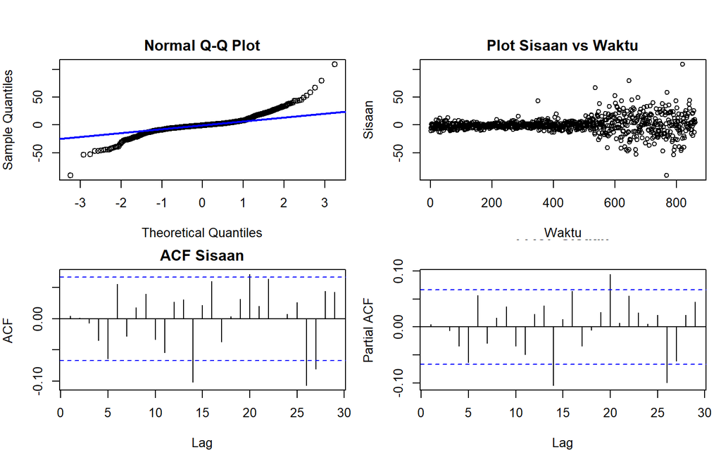

```r
par(
  mfrow = c(2,2),
  mar = c(4,4,2,1),
  oma = c(0,0,2,0)
)

# Q-Q Plot
qqnorm(
  sisaan,
  main = "Normal Q-Q Plot"
)

qqline(
  sisaan,
  col = "blue",
  lwd = 2
)

# Sisaan vs waktu
plot(
  sisaan,
  type = "p",
  main = "Plot Sisaan vs Waktu",
  xlab = "Waktu",
  ylab = "Sisaan"
)

# ACF
acf(
  sisaan,
  main = "ACF Sisaan"
)

# PACF
pacf(
  sisaan,
  main = "PACF Sisaan"
)
```

```r
par(mfrow = c(1,1))
```

# Uji Formal Sisaan

## Uji Normalitas KS

$H_0 : \text{Sisaan menyebar normal}$  
$H_1 : \text{Sisaan tidak menyebar normal}$

```r
ks.test(
  scale(sisaan),
  "pnorm"
)
```

```
##
##  Asymptotic one-sample Kolmogorov-Smirnov test
##
## data:  scale(sisaan)
## D = 0.14271, p-value = 1.176e-15
## alternative hypothesis: two-sided
```

Karena p-value < 0.05, maka Tolak Ho. Sisaan tidak mengikuti distribusi normal.

## Uji Kebebasan Sisaan

$H_0 : \text{Sisaan saling bebas}$  
$H_1 : \text{Sisaan tidak saling bebas}$

```r
Box.test(
  sisaan,
  type = "Ljung"
)
```

```
##
##  Box-Ljung test
##
## data:  sisaan
## X-squared = 0.018465, df = 1, p-value = 0.8919
```

Karena p-value > 0.05, maka Gagal Tolak H0. Artinya, Sisaan saling bebas.

## Uji Kehomogenan Ragam

$H_0 : \text{Ragam sisaan homogen}$  
$H_1 : \text{Ragam sisaan tidak homogen}$

```r
Box.test(
  sisaan^2,
  type = "Ljung"
)
```

```
##
##  Box-Ljung test
##
## data:  sisaan^2
## X-squared = 28.093, df = 1, p-value = 1.156e-07
```

Karena p-value < 0.05, maka Tolak H0. Artinya, ragam sisaan tidak homogen.

## Uji Nilai Tengah Sisaan

$H_0 : \mu_e = 0$  
$H_1 : \mu_e \neq 0$

```r
t.test(
  sisaan,
  mu = 0,
  conf.level = 0.95
)
```

```
##
##  One Sample t-test
##
## data:  sisaan
## t = -0.0024939, df = 860, p-value = 0.998
## alternative hypothesis: true mean is not equal to 0
## 95 percent confidence interval:
##  -0.9665090  0.9640559
## sample estimates:
##    mean of x
## -0.001226522
```

Karena p-value > 0.05, maka Gagal Tolak H0. Artinya, tidak terdapat bukti bahwa nilai tengah sisaan berbeda dari nol.

# Overfitting

```r
over1 <- Arima(
  train.final,
  order = c(1,0,3),
  method = "ML"
)

over2 <- Arima(
  train.final,
  order = c(0,0,4),
  method = "ML"
)

summary(over1)
```

```
## Series: train.final
## ARIMA(1,0,3) with non-zero mean
##
## Coefficients:
##          ar1      ma1     ma2      ma3     mean
##       0.4220  -0.5069  0.1289  -0.1400  91.6674
## s.e.  0.2144   0.2127  0.0420   0.0341   0.4096
##
## sigma^2 = 208.6:  log likelihood = -3518.34
## AIC=7048.69   AICc=7048.79   BIC=7077.24
##
## Training set error measures:
##                       ME     RMSE      MAE  MPE MAPE      MASE         ACF1
## Training set -0.00347076 14.40204 8.874103 -Inf  Inf 0.6906224 0.0004646255
```

```r
lmtest::coeftest(over1)
```

```
##
## z test of coefficients:
##
##            Estimate Std. Error  z value  Pr(>|z|)
## ar1        0.421979   0.214393   1.9683   0.04904 *
## ma1       -0.506874   0.212706  -2.3830   0.01717 *
## ma2        0.128888   0.041982   3.0701   0.00214 **
## ma3       -0.140024   0.034117  -4.1042 4.057e-05 ***
## intercept 91.667426   0.409589 223.8033 < 2.2e-16 ***
## ---
## Signif. codes:  0 '***' 0.001 '**' 0.01 '*' 0.05 '.' 0.1 ' ' 1
```

```r
summary(over2)
```

```
## Series: train.final
## ARIMA(0,0,4) with non-zero mean
##
## Coefficients:
##           ma1     ma2      ma3      ma4     mean
##       -0.0870  0.0922  -0.1001  -0.0443  91.6673
## s.e.   0.0339  0.0341   0.0325   0.0326   0.4228
##
## sigma^2 = 208.8:  log likelihood = -3518.65
## AIC=7049.3   AICc=7049.4   BIC=7077.85
##
## Training set error measures:
##                       ME     RMSE      MAE  MPE MAPE      MASE        ACF1
## Training set -0.00222009 14.40723 8.876905 -Inf  Inf 0.6908405 0.001922302
```

```r
lmtest::coeftest(over2)
```

```
##
## z test of coefficients:
##
##            Estimate Std. Error  z value  Pr(>|z|)
## ma1       -0.087017   0.033918  -2.5655  0.010302 *
## ma2        0.092153   0.034091   2.7032  0.006868 **
## ma3       -0.100091   0.032479  -3.0817  0.002058 **
## ma4       -0.044309   0.032629  -1.3580  0.174475
## intercept 91.667311   0.422837 216.7913 < 2.2e-16 ***
## ---
## Signif. codes:  0 '***' 0.001 '**' 0.01 '*' 0.05 '.' 0.1 ' ' 1
```

```r
overfitting <- data.frame(
  Model = c(
    "ARIMA(0,1,3)",
    "ARIMA(1,1,3)",
    "ARIMA(0,1,4)"
  ),

  AIC = c(
    AIC(model.best),
    AIC(over1),
    AIC(over2)
  ),

  BIC = c(
    BIC(model.best),
    BIC(over1),
    BIC(over2)
  )
)

overfitting
```

```
##          Model      AIC      BIC
## 1 ARIMA(0,1,3) 7049.130 7072.921
## 2 ARIMA(1,1,3) 7048.687 7077.235
## 3 ARIMA(0,1,4) 7049.305 7077.853
```

Hasil overfitting check menunjukkan bahwa penambahan parameter pada model ARIMA(0,1,3) tidak memberikan perbaikan yang berarti. ARIMA(1,1,3) memiliki nilai AIC sedikit lebih rendah, tetapi nilai BIC lebih tinggi dibandingkan ARIMA(0,1,3). Sementara itu, ARIMA(0,1,4) memiliki nilai AIC dan BIC yang lebih tinggi. Jadi model yang digunakan untuk peramalan tetap: ARIMA(0,1,3).

# Forecast/Peramalan

```r
ramalan <- forecast::forecast(
  model.best,
  h = length(test.ts)
)

ramalan
```

```
##      Point Forecast    Lo 80    Hi 80    Lo 95    Hi 95
##  862       90.85389 72.32749 109.3803 62.52020 119.1876
##  863       91.47564 72.87843 110.0729 63.03366 119.9176
##  864       91.20294 72.52875 109.8771 62.64324 119.7626
##  865       91.66695 72.90188 110.4320 62.96825 120.3656
##  866       91.66695 72.90188 110.4320 62.96825 120.3656
##  867       91.66695 72.90188 110.4320 62.96825 120.3656
##  868       91.66695 72.90188 110.4320 62.96825 120.3656
##  869       91.66695 72.90188 110.4320 62.96825 120.3656
##  870       91.66695 72.90188 110.4320 62.96825 120.3656
##  871       91.66695 72.90188 110.4320 62.96825 120.3656
##  872       91.66695 72.90188 110.4320 62.96825 120.3656
##  873       91.66695 72.90188 110.4320 62.96825 120.3656
##  874       91.66695 72.90188 110.4320 62.96825 120.3656
##  875       91.66695 72.90188 110.4320 62.96825 120.3656
```

[output cut: 127 more lines]

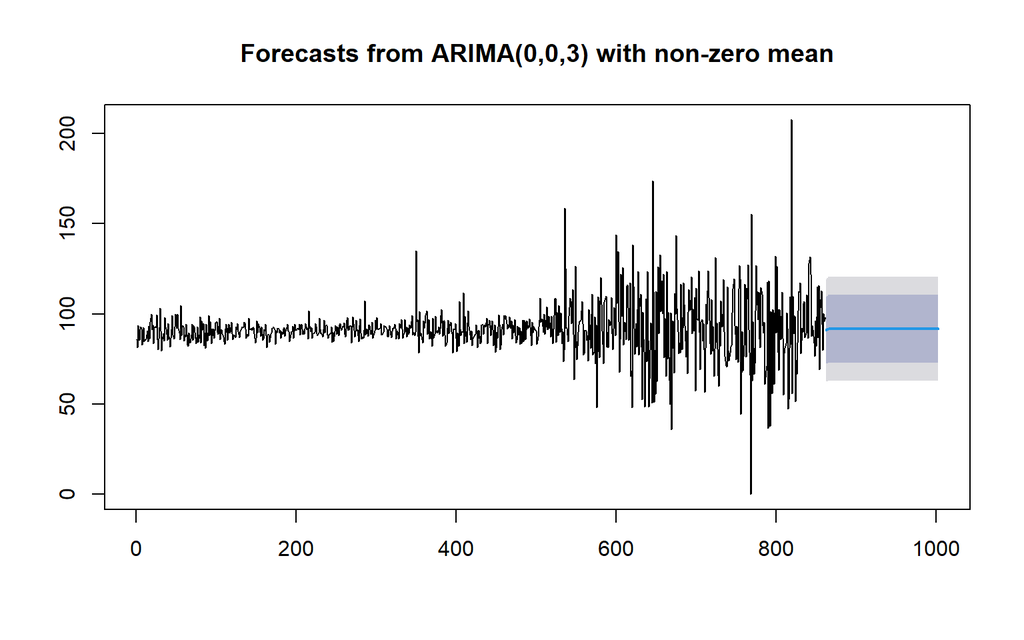

```r
plot(ramalan)
```

# Inverse Transformasi dan Differencing

Karena model dibangun berdasarkan data hasil differencing yang kemudian ditransformasi dengan Box-Cox, hasil ramalan perlu dikembalikan terlebih dahulu ke skala setelah differencing, kemudian dikembalikan ke skala harga asli

```r
data.ramalan.trans <- ramalan$mean

# Inverse transformasi Box-Cox
if (transformasi_dilakukan) {

  if (abs(lambda_opt_diff) < 1e-8) {
    data.ramalan.shifted <- exp(data.ramalan.trans)
  } else {
    data.ramalan.shifted <- (
      lambda_opt_diff * data.ramalan.trans + 1
    )^(1 / lambda_opt_diff)
  }

  # Mengembalikan hasil dari data yang sebelumnya digeser
  data.ramalan <- data.ramalan.shifted - c_shift

} else {

  # Jika tidak dilakukan transformasi, hasil forecast sudah berada pada skala differencing.
  data.ramalan <- data.ramalan.trans
}

# Inverse differencing
pt_akhir_train <- tail(train.ts, 1)

forecast.inv <- diffinv(
  data.ramalan,
  differences = 1,
  xi = pt_akhir_train
)

hasil <- forecast.inv[-1]

hasil <- hasil[1:length(test.ts)]
```

# Akurasi Forecast

```r
akurasi_test <- accuracy(
  hasil,
  test.ts
)

akurasi_test
```

```
##                ME     RMSE      MAE      MPE     MAPE
## Test set 18.67419 20.80339 18.77526 10.28578 10.35571
```

Model ARIMA(0,1,3) menghasilkan MAPE sebesar 10,36%, yang menunjukkan bahwa rata-rata kesalahan absolut hasil peramalan pada data test adalah sekitar 10,36%..

# Plot Aktual vs Forecast

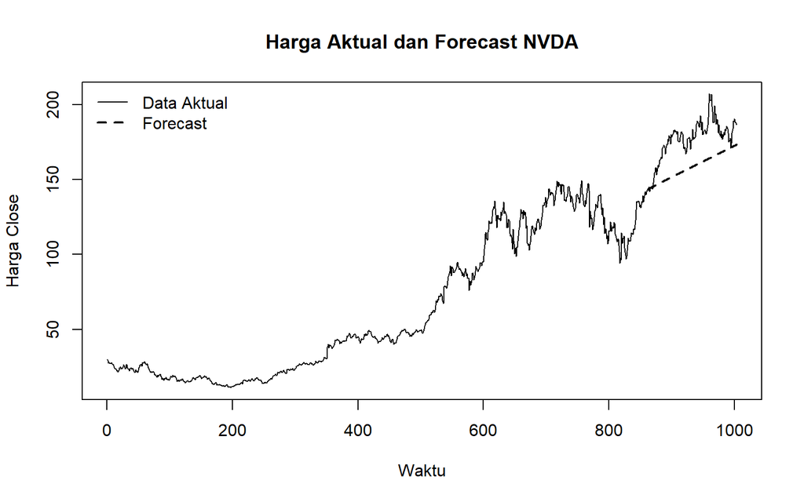

```r
ts.plot(
  nvda.ts,
  lty = 1,
  xlab = "Waktu",
  ylab = "Harga Close",
  main = "Harga Aktual dan Forecast NVDA"
)

lines(
  (n_train + 1):(n_train + length(hasil)),
  hasil,
  lty = 2,
  lwd = 2
)

legend(
  "topleft",
  legend = c("Data Aktual", "Forecast"),
  lty = c(1,2),
  lwd = c(1,2),
  bty = "n"
)
```